# Recalling Words

```r
library(mosaic)
library(car)
library(pander)
library(DT) #You may need to run: install.packages("DT")
library(tidyverse)
```

```r
# Play the chunk above and this one to get the data into your Console
# Note the eval=FALSE statement in this R-chunk will exclude this code
# from running when you Knit and will only work in the Console.
# View(Friendly)
# ?Friendly
```

## Background

Many teachers and other educators are interested in understanding how to best deliver new content to students. In general, they have two choices of how to do this.

1. The Meshed Approach
   - Deliver new content while simultaneously reviewing previously understood content.
2. The Before Approach
   - Deliver new content after fully reviewing previously understood content.

A study was performed to determine whether the *Meshed* or *Before* approaches to delivering content had any positive benefits on memory recall.

### Show the Experiment Details

Individuals were seated at a computer and shown a list of words. Words appeared on the screen one at a time, for two seconds each, until all words had been shown (40 total). After all words were shown, they were required to perform a few two-digit mathematical additions (like 15 + 25) for 15 seconds to avoid immediate memory recall of the words. They were then asked to write down as many of the 40 words as they could remember. They were given a maximum of 5.3 minutes to recall words.

The process of showing words and recalling words was repeated four times with the same list of words each time (four chances to get it right). The presentation of the first trial was the same for all treatment conditions. However, trials 2, 3, and 4 were slightly different for each treatment condition.

The `SFR` group (the control group) stands for Standard Free Recall. In all four trials the same list of 40 words was presented, in a random order each time.

The `Before` group also used the same 40 words during each trial. However, any words that were correctly recalled in a previous trial were presented first, or *before* the words that were not recalled in the last trial. After all the correct words were presented in random order, the non-recalled words were presented in a random order.

The `Meshed` group also used the same 40 words during each trial. However, words that were correctly recalled in a previous trial were alternated with a missed word during the next presentation order.

The data records the number of correctly recalled words (out of the 40 possible) from the fourth trial. Results were obtained for 30 students, 10 in each of the three treatment groups: `SFR`, `Before`, and `Meshed`.

### Show the Data

The results from the study can be found in the `Friendly` data set in R after loading `library(car)`.

Click the “Code” button to see the data.

```r
#|echo: false
#|warning: false
datatable(Friendly, options=list(lengthMenu = c(3,10,30)))
```

|  | condition | correct |
| --- | --- | --- |
| 1 | SFR | 39 |
| 2 | SFR | 25 |
| 3 | SFR | 37 |
| 4 | SFR | 25 |
| 5 | SFR | 29 |
| 6 | SFR | 39 |
| 7 | SFR | 21 |
| 8 | SFR | 39 |
| 9 | SFR | 24 |
| 10 | SFR | 25 |

[output cut: 20 more lines]

## Analysis

### Introduction and Hypothesis

- The purpose of this study is to determine whether the *Meshed* or *Before* approaches to delivering content had any positive benefits on memory recall. The hypothesis is that their is not a difference between the two groups in memory recall. Our Alternative Hypothesis is that there is a difference between the two groups in memory recall.
  $$H_O: \text{There is no difference in memory recall between Meshed and
  Before teaching styles.}$$

$$H_A: \text{There is a difference in teaching styles with memory recall
between Meshed and Before.}$$
$$a = 0.05$$

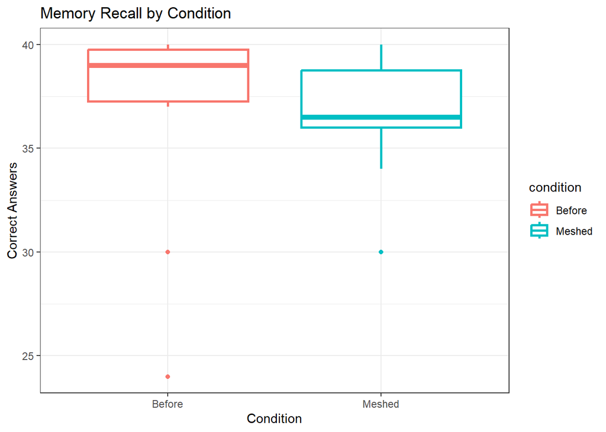

```r
#|echo: false
#|warning: false


#Intro and hypothesis
friendly_data <- Friendly %>%
  filter(condition != "SFR")

friendly_data=droplevels(friendly_data)

ggplot(friendly_data, aes(x = condition, y = correct, color=condition)) +
  geom_boxplot(linewidth=1, size =2) +
  labs(title = "Memory Recall by Condition",
       x = "Condition",
       y = "Correct Answers") +
  theme_bw()
```

```r
# View(friendly_data)
```

### Data Statistics

- Fav Stats Test

```r
#|echo: false
#|warning: false


pander(favstats(correct ~ condition, data = friendly_data))
```

| condition | min | Q1 | median | Q3 | max | mean | sd | n | missing |
| --- | --- | --- | --- | --- | --- | --- | --- | --- | --- |
| Before | 24 | 37.25 | 39 | 39.75 | 40 | 36.6 | 5.337 | 10 | 0 |
| Meshed | 30 | 36 | 36.5 | 38.75 | 40 | 36.6 | 3.026 | 10 | 0 |

- From a fav stats test the data shows that the data between the two groups are very similar as they have the same mean but do have separate medians.
- Now we need to confirm the hypothesis by running a T-Test and a Wilcox Test to determine if there is a significant difference between the groups. We will also need to check the assumptions of the t-test using a qqPlot. If we achieve a P-Value of greater than 0.05 we will fail to reject our null hypothesis and accept that there is no difference between the two groups in memory recall.

### T-Test Results

```r
#|echo: false
#|warning: false

#T-Test to do

pander(t.test(correct ~ condition, data = friendly_data))
```

Welch Two Sample t-test: `correct` by `condition` (continued below)

| Test statistic | df | P value | Alternative hypothesis |
| --- | --- | --- | --- |
| 0 | 14.24 | 1 | two.sided |

| mean in group Before | mean in group Meshed |
| --- | --- |
| 36.6 | 36.6 |

- We see from the T-Test that the t-value and the p-value are 0 and 1 respectively which means that we fail to reject the null hypothesis. This means that there is no difference between the two groups in memory recall.

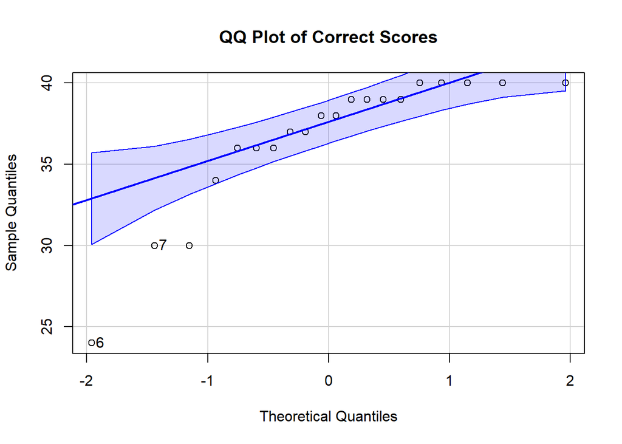

```
## [1] 6 7
```

```r
#|echo: false
#|warning: false


#qqPlot


qqPlot(friendly_data$correct, distribution = "norm",
      main = "QQ Plot of Correct Scores",
      xlab = "Theoretical Quantiles",
      ylab = "Sample Quantiles")
```

### QQ Plot

- The QQ plot shows that the data is near normal distributed but does have some data skew referencing some absence of normality within some of the data. We see a majority fall within the normality range which can help us determine whether to use the data or not.

```r
#|echo: false
#|warning: false


#Wilcox Test

pander(wilcox.test(correct ~ condition, data = friendly_data, exact= FALSE))
```

Wilcoxon rank sum test with continuity correction: `correct` by `condition`

| Test statistic | P value | Alternative hypothesis |
| --- | --- | --- |
| 62 | 0.378 | two.sided |

### Wilcox Test Results

- Since the p-value is relatively large (0.378), it suggests that there is no significant difference between the medians of the two groups being compared.The null hypothesis is not rejected.